# Business_Analytics_Credit_Card_Fraud_Detection_Capstone_Project

## **Credit Card Fraud Detection**

### **Google Drive Import**

```python
from google.colab import drive
drive.mount('/content/drive')
```

## Step1:Importing Dataset

```python
import numpy as np
import pandas as pd
from scipy.stats import skew
import matplotlib.pyplot as plt
import seaborn as sns
import sklearn
import warnings
warnings.filterwarnings('ignore')
```

```python
train_data=pd.read_csv('/content/drive/MyDrive/Capstone Project/fraudTrain.csv', encoding='Latin1')
train_data.head()
```

|  | Unnamed: 0 | trans_date_trans_time | cc_num | merchant | category | amt | first | last | gender | street | ... | lat | long | city_pop | job | dob | trans_num | unix_time | merch_lat | merch_long | is_fraud |
| --- | --- | --- | --- | --- | --- | --- | --- | --- | --- | --- | --- | --- | --- | --- | --- | --- | --- | --- | --- | --- | --- |
| 0 | 0 | 2019-01-01 00:00:18 | 2703186189652095 | fraud_Rippin, Kub and Mann | misc_net | 4.97 | Jennifer | Banks | F | 561 Perry Cove | ... | 36.0788 | -81.1781 | 3495 | Psychologist, counselling | 1988-03-09 | 0b242abb623afc578575680df30655b9 | 1325376018 | 36.011293 | -82.048315 | 0 |
| 1 | 1 | 2019-01-01 00:00:44 | 630423337322 | fraud_Heller, Gutmann and Zieme | grocery_pos | 107.23 | Stephanie | Gill | F | 43039 Riley Greens Suite 393 | ... | 48.8878 | -118.2105 | 149 | Special educational needs teacher | 1978-06-21 | 1f76529f8574734946361c461b024d99 | 1325376044 | 49.159047 | -118.186462 | 0 |
| 2 | 2 | 2019-01-01 00:00:51 | 38859492057661 | fraud_Lind-Buckridge | entertainment | 220.11 | Edward | Sanchez | M | 594 White Dale Suite 530 | ... | 42.1808 | -112.2620 | 4154 | Nature conservation officer | 1962-01-19 | a1a22d70485983eac12b5b88dad1cf95 | 1325376051 | 43.150704 | -112.154481 | 0 |
| 3 | 3 | 2019-01-01 00:01:16 | 3534093764340240 | fraud_Kutch, Hermiston and Farrell | gas_transport | 45.00 | Jeremy | White | M | 9443 Cynthia Court Apt. 038 | ... | 46.2306 | -112.1138 | 1939 | Patent attorney | 1967-01-12 | 6b849c168bdad6f867558c3793159a81 | 1325376076 | 47.034331 | -112.561071 | 0 |
| 4 | 4 | 2019-01-01 00:03:06 | 375534208663984 | fraud_Keeling-Crist | misc_pos | 41.96 | Tyler | Garcia | M | 408 Bradley Rest | ... | 38.4207 | -79.4629 | 99 | Dance movement psychotherapist | 1986-03-28 | a41d7549acf90789359a9aa5346dcb46 | 1325376186 | 38.674999 | -78.632459 | 0 |

5 rows × 23 columns

```python
test_data=pd.read_csv('/content/drive/MyDrive/Capstone Project/fraudTest.csv', encoding='Latin1')
test_data.head()
```

|  | Unnamed: 0 | trans_date_trans_time | cc_num | merchant | category | amt | first | last | gender | street | ... | lat | long | city_pop | job | dob | trans_num | unix_time | merch_lat | merch_long | is_fraud |
| --- | --- | --- | --- | --- | --- | --- | --- | --- | --- | --- | --- | --- | --- | --- | --- | --- | --- | --- | --- | --- | --- |
| 0 | 0 | 2020-06-21 12:14:25 | 2291163933867244 | fraud_Kirlin and Sons | personal_care | 2.86 | Jeff | Elliott | M | 351 Darlene Green | ... | 33.9659 | -80.9355 | 333497 | Mechanical engineer | 1968-03-19 | 2da90c7d74bd46a0caf3777415b3ebd3 | 1371816865 | 33.986391 | -81.200714 | 0 |
| 1 | 1 | 2020-06-21 12:14:33 | 3573030041201292 | fraud_Sporer-Keebler | personal_care | 29.84 | Joanne | Williams | F | 3638 Marsh Union | ... | 40.3207 | -110.4360 | 302 | Sales professional, IT | 1990-01-17 | 324cc204407e99f51b0d6ca0055005e7 | 1371816873 | 39.450498 | -109.960431 | 0 |
| 2 | 2 | 2020-06-21 12:14:53 | 3598215285024754 | fraud_Swaniawski, Nitzsche and Welch | health_fitness | 41.28 | Ashley | Lopez | F | 9333 Valentine Point | ... | 40.6729 | -73.5365 | 34496 | Librarian, public | 1970-10-21 | c81755dbbbea9d5c77f094348a7579be | 1371816893 | 40.495810 | -74.196111 | 0 |
| 3 | 3 | 2020-06-21 12:15:15 | 3591919803438423 | fraud_Haley Group | misc_pos | 60.05 | Brian | Williams | M | 32941 Krystal Mill Apt. 552 | ... | 28.5697 | -80.8191 | 54767 | Set designer | 1987-07-25 | 2159175b9efe66dc301f149d3d5abf8c | 1371816915 | 28.812398 | -80.883061 | 0 |
| 4 | 4 | 2020-06-21 12:15:17 | 3526826139003047 | fraud_Johnston-Casper | travel | 3.19 | Nathan | Massey | M | 5783 Evan Roads Apt. 465 | ... | 44.2529 | -85.0170 | 1126 | Furniture designer | 1955-07-06 | 57ff021bd3f328f8738bb535c302a31b | 1371816917 | 44.959148 | -85.884734 | 0 |

5 rows × 23 columns

## Step2:Exploring Data

```python
train_data.info()
```

```
<class 'pandas.core.frame.DataFrame'>
RangeIndex: 1296675 entries, 0 to 1296674
Data columns (total 23 columns):
 #   Column                 Non-Null Count    Dtype
---  ------                 --------------    -----
 0   Unnamed: 0             1296675 non-null  int64
 1   trans_date_trans_time  1296675 non-null  object
 2   cc_num                 1296675 non-null  int64
 3   merchant               1296675 non-null  object
 4   category               1296675 non-null  object
 5   amt                    1296675 non-null  float64
 6   first                  1296675 non-null  object
 7   last                   1296675 non-null  object
 8   gender                 1296675 non-null  object
 9   street                 1296675 non-null  object
 10  city                   1296675 non-null  object
 11  state                  1296675 non-null  object
 12  zip                    1296675 non-null  int64
 13  lat                    1296675 non-null  float64
 14  long                   1296675 non-null  float64
 15  city_pop               1296675 non-null  int64
 16  job                    1296675 non-null  object
 17  dob                    1296675 non-null  object
 18  trans_num              1296675 non-null  object
 19  unix_time              1296675 non-null  int64
 20  merch_lat              1296675 non-null  float64
 21  merch_long             1296675 non-null  float64
 22  is_fraud               1296675 non-null  int64
dtypes: float64(5), int64(6), object(12)
memory usage: 227.5+ MB
```

```python
test_data.info()
```

```
<class 'pandas.core.frame.DataFrame'>
RangeIndex: 555719 entries, 0 to 555718
Data columns (total 23 columns):
 #   Column                 Non-Null Count   Dtype
---  ------                 --------------   -----
 0   Unnamed: 0             555719 non-null  int64
 1   trans_date_trans_time  555719 non-null  object
 2   cc_num                 555719 non-null  int64
 3   merchant               555719 non-null  object
 4   category               555719 non-null  object
 5   amt                    555719 non-null  float64
 6   first                  555719 non-null  object
 7   last                   555719 non-null  object
 8   gender                 555719 non-null  object
 9   street                 555719 non-null  object
 10  city                   555719 non-null  object
 11  state                  555719 non-null  object
 12  zip                    555719 non-null  int64
 13  lat                    555719 non-null  float64
 14  long                   555719 non-null  float64
 15  city_pop               555719 non-null  int64
 16  job                    555719 non-null  object
 17  dob                    555719 non-null  object
 18  trans_num              555719 non-null  object
 19  unix_time              555719 non-null  int64
 20  merch_lat              555719 non-null  float64
 21  merch_long             555719 non-null  float64
 22  is_fraud               555719 non-null  int64
dtypes: float64(5), int64(6), object(12)
memory usage: 97.5+ MB
```

```python
train_data.describe()
```

|  | Unnamed: 0 | cc_num | amt | zip | lat | long | city_pop | unix_time | merch_lat | merch_long | is_fraud |
| --- | --- | --- | --- | --- | --- | --- | --- | --- | --- | --- | --- |
| count | 1.296675e+06 | 1.296675e+06 | 1.296675e+06 | 1.296675e+06 | 1.296675e+06 | 1.296675e+06 | 1.296675e+06 | 1.296675e+06 | 1.296675e+06 | 1.296675e+06 | 1.296675e+06 |
| mean | 6.483370e+05 | 4.171920e+17 | 7.035104e+01 | 4.880067e+04 | 3.853762e+01 | -9.022634e+01 | 8.882444e+04 | 1.349244e+09 | 3.853734e+01 | -9.022646e+01 | 5.788652e-03 |
| std | 3.743180e+05 | 1.308806e+18 | 1.603160e+02 | 2.689322e+04 | 5.075808e+00 | 1.375908e+01 | 3.019564e+05 | 1.284128e+07 | 5.109788e+00 | 1.377109e+01 | 7.586269e-02 |
| min | 0.000000e+00 | 6.041621e+10 | 1.000000e+00 | 1.257000e+03 | 2.002710e+01 | -1.656723e+02 | 2.300000e+01 | 1.325376e+09 | 1.902779e+01 | -1.666712e+02 | 0.000000e+00 |
| 25% | 3.241685e+05 | 1.800429e+14 | 9.650000e+00 | 2.623700e+04 | 3.462050e+01 | -9.679800e+01 | 7.430000e+02 | 1.338751e+09 | 3.473357e+01 | -9.689728e+01 | 0.000000e+00 |
| 50% | 6.483370e+05 | 3.521417e+15 | 4.752000e+01 | 4.817400e+04 | 3.935430e+01 | -8.747690e+01 | 2.456000e+03 | 1.349250e+09 | 3.936568e+01 | -8.743839e+01 | 0.000000e+00 |
| 75% | 9.725055e+05 | 4.642255e+15 | 8.314000e+01 | 7.204200e+04 | 4.194040e+01 | -8.015800e+01 | 2.032800e+04 | 1.359385e+09 | 4.195716e+01 | -8.023680e+01 | 0.000000e+00 |
| max | 1.296674e+06 | 4.992346e+18 | 2.894890e+04 | 9.978300e+04 | 6.669330e+01 | -6.795030e+01 | 2.906700e+06 | 1.371817e+09 | 6.751027e+01 | -6.695090e+01 | 1.000000e+00 |

```python
test_data.describe()
```

|  | Unnamed: 0 | cc_num | amt | zip | lat | long | city_pop | unix_time | merch_lat | merch_long | is_fraud |
| --- | --- | --- | --- | --- | --- | --- | --- | --- | --- | --- | --- |
| count | 555719.000000 | 5.557190e+05 | 555719.000000 | 555719.000000 | 555719.000000 | 555719.000000 | 5.557190e+05 | 5.557190e+05 | 555719.000000 | 555719.000000 | 555719.000000 |
| mean | 277859.000000 | 4.178387e+17 | 69.392810 | 48842.628015 | 38.543253 | -90.231325 | 8.822189e+04 | 1.380679e+09 | 38.542798 | -90.231380 | 0.003860 |
| std | 160422.401459 | 1.309837e+18 | 156.745941 | 26855.283328 | 5.061336 | 13.721780 | 3.003909e+05 | 5.201104e+06 | 5.095829 | 13.733071 | 0.062008 |
| min | 0.000000 | 6.041621e+10 | 1.000000 | 1257.000000 | 20.027100 | -165.672300 | 2.300000e+01 | 1.371817e+09 | 19.027422 | -166.671575 | 0.000000 |
| 25% | 138929.500000 | 1.800429e+14 | 9.630000 | 26292.000000 | 34.668900 | -96.798000 | 7.410000e+02 | 1.376029e+09 | 34.755302 | -96.905129 | 0.000000 |
| 50% | 277859.000000 | 3.521417e+15 | 47.290000 | 48174.000000 | 39.371600 | -87.476900 | 2.408000e+03 | 1.380762e+09 | 39.376593 | -87.445204 | 0.000000 |
| 75% | 416788.500000 | 4.635331e+15 | 83.010000 | 72011.000000 | 41.894800 | -80.175200 | 1.968500e+04 | 1.385867e+09 | 41.954163 | -80.264637 | 0.000000 |
| max | 555718.000000 | 4.992346e+18 | 22768.110000 | 99921.000000 | 65.689900 | -67.950300 | 2.906700e+06 | 1.388534e+09 | 66.679297 | -66.952026 | 1.000000 |

```python
print(train_data.shape)
print(test_data.shape)
```

```
(1296675, 23)
(555719, 23)
```

# Step 3:Cleaning Data

```python
train_data.isnull().sum()
```

```
Unnamed: 0               0
trans_date_trans_time    0
cc_num                   0
merchant                 0
category                 0
amt                      0
first                    0
last                     0
gender                   0
street                   0
city                     0
state                    0
zip                      0
lat                      0
long                     0
city_pop                 0
job                      0
dob                      0
trans_num                0
unix_time                0
merch_lat                0
merch_long               0
is_fraud                 0
dtype: int64
```

```python
test_data.isnull().sum()
```

```
Unnamed: 0               0
trans_date_trans_time    0
cc_num                   0
merchant                 0
category                 0
amt                      0
first                    0
last                     0
gender                   0
street                   0
city                     0
state                    0
zip                      0
lat                      0
long                     0
city_pop                 0
job                      0
dob                      0
trans_num                0
unix_time                0
merch_lat                0
merch_long               0
is_fraud                 0
dtype: int64
```

```python
train_data.duplicated().sum()
test_data.duplicated().sum()
```

```
0
```

```python
train_data['is_fraud'].value_counts() #checking for fraud values
```

```
0    1289169
1       7506
Name: is_fraud, dtype: int64
```

```python
test_data['is_fraud'].value_counts()
```

```
0    553574
1      2145
Name: is_fraud, dtype: int64
```

```python
# Converting date columns to datetime format

train_data['trans_date_trans_time']=pd.to_datetime(train_data['trans_date_trans_time'])
train_data['trans_date']=train_data['trans_date_trans_time'].dt.strftime('%Y-%m-%d')
train_data['trans_date']=pd.to_datetime(train_data['trans_date'])
train_data['dob']=pd.to_datetime(train_data['dob'])

test_data['trans_date_trans_time']=pd.to_datetime(test_data['trans_date_trans_time'])
test_data['trans_date']=test_data['trans_date_trans_time'].dt.strftime('%Y-%m-%d')
test_data['trans_date']=pd.to_datetime(test_data['trans_date'])
test_data['dob']=pd.to_datetime(test_data['dob'])
```

```python
#Drop unnecessary colums
drop_columns=['Unnamed: 0','zip','city_pop','unix_time',"merchant","first","last","street",'trans_num']
train_data.drop(columns=drop_columns,inplace=True)
test_data.drop(columns=drop_columns,inplace=True)
```

```python
# Convert categorical column gender into numerical
train_data.gender=train_data.gender.apply(lambda x: 1 if x=="M" else 0)
test_data.gender=test_data.gender.apply(lambda x: 1 if x=="M" else 0)
```

```python
train_data.head()
```

|  | trans_date_trans_time | cc_num | category | amt | gender | city | state | lat | long | job | dob | merch_lat | merch_long | is_fraud | trans_date |
| --- | --- | --- | --- | --- | --- | --- | --- | --- | --- | --- | --- | --- | --- | --- | --- |
| 0 | 2019-01-01 00:00:18 | 2703186189652095 | misc_net | 4.97 | 0 | Moravian Falls | NC | 36.0788 | -81.1781 | Psychologist, counselling | 1988-03-09 | 36.011293 | -82.048315 | 0 | 2019-01-01 |
| 1 | 2019-01-01 00:00:44 | 630423337322 | grocery_pos | 107.23 | 0 | Orient | WA | 48.8878 | -118.2105 | Special educational needs teacher | 1978-06-21 | 49.159047 | -118.186462 | 0 | 2019-01-01 |
| 2 | 2019-01-01 00:00:51 | 38859492057661 | entertainment | 220.11 | 1 | Malad City | ID | 42.1808 | -112.2620 | Nature conservation officer | 1962-01-19 | 43.150704 | -112.154481 | 0 | 2019-01-01 |
| 3 | 2019-01-01 00:01:16 | 3534093764340240 | gas_transport | 45.00 | 1 | Boulder | MT | 46.2306 | -112.1138 | Patent attorney | 1967-01-12 | 47.034331 | -112.561071 | 0 | 2019-01-01 |
| 4 | 2019-01-01 00:03:06 | 375534208663984 | misc_pos | 41.96 | 1 | Doe Hill | VA | 38.4207 | -79.4629 | Dance movement psychotherapist | 1986-03-28 | 38.674999 | -78.632459 | 0 | 2019-01-01 |

## Step 4: CHECKING CLASS IMBALANCE

```python
#class imbalance for train data set
classes= train_data['is_fraud'].value_counts()
normal_share=classes[0]/train_data['is_fraud'].count()*100
fraud_share=classes[1]/train_data['is_fraud'].count()*100
```

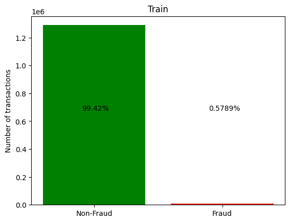

```python
#plotting bar graph for more clear understanding
plt.bar(['Non-Fraud','Fraud'], classes, color=['g','r'])
plt.ylabel('Number of transactions')
plt.title('Train')
plt.annotate("{0:.4}%".format(normal_share),(0.2, 0.5), xycoords='axes fraction')
plt.annotate("{0:.4}%".format(fraud_share),(0.7, 0.5), xycoords='axes fraction')
plt.show()
```

OBSERVATION: 99.42% of transactions are not fraudulent and 0.58% of transactions are fraudulent for train_data

[figure not shown]

```python
#checking class imbalance for test_data set
classes_test=test_data['is_fraud'].value_counts()
normal_share_test=classes_test[0]/test_data['is_fraud'].count()*100
fraud_share_test=classes_test[1]/test_data['is_fraud'].count()*100

#plotting bar graph for more clear understanding
plt.bar(['Non-Fraud','Fraud'], classes_test, color=['y','r'])
plt.ylabel('Number of transactions')
plt.title('Test')
plt.annotate("{0:.4}%".format(normal_share),(0.2, 0.5), xycoords='axes fraction')
plt.annotate("{0:.4}%".format(fraud_share),(0.7, 0.5), xycoords='axes fraction')
plt.show()
```

```python
train_data['category'].unique() #checking for different categories
```

```
array(['misc_net', 'grocery_pos', 'entertainment', 'gas_transport',
       'misc_pos', 'grocery_net', 'shopping_net', 'shopping_pos',
       'food_dining', 'personal_care', 'health_fitness', 'travel',
       'kids_pets', 'home'], dtype=object)
```

Train dataset containing only fraud transaction data for visualization purpose

```python
viz_fraud = train_data[train_data['is_fraud'] == 1]
```

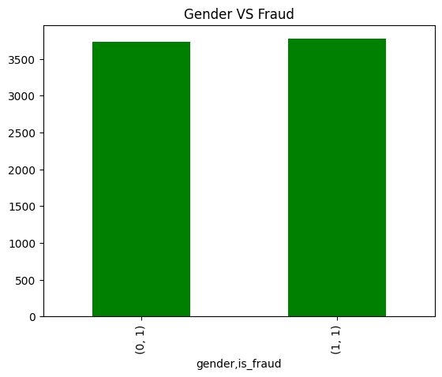

```python
#plot the graph between gender and no.of frauds done
viz_fraud.groupby(['gender'])['is_fraud'].value_counts().plot.bar(color='g')
plt.title('Gender VS Fraud')
plt.show()
```

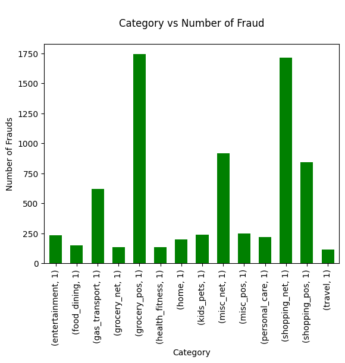

```python
#plot a bar graph to show the category-wise fraud
viz_fraud.groupby(['category'])['is_fraud'].value_counts().plot.bar(color='g',width=0.6)
plt.title('\nCategory vs Number of Fraud\n')
plt.ylabel('Number of Frauds')
plt.xlabel('Category')
plt.figure(figsize=(8,8))
plt.show()
```

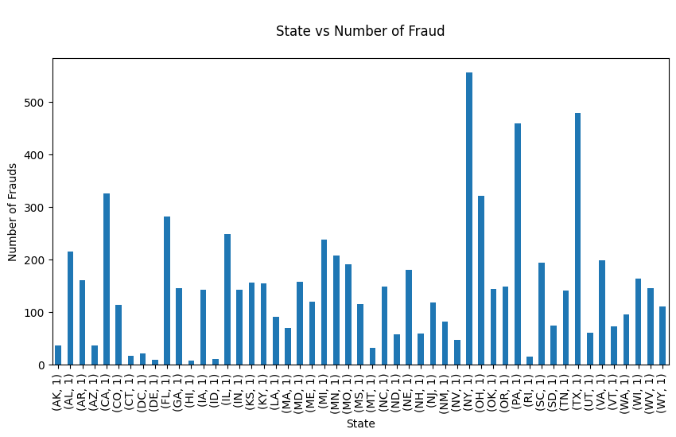

```python
plt.figure(figsize=[10,5])
viz_fraud.groupby(['state'])['is_fraud'].value_counts().plot.bar()
plt.title('\nState vs Number of Fraud\n')
plt.ylabel('Number of Frauds')
plt.xlabel('State')
plt.show()
```

```python
train_data.columns
```

```
Index(['trans_date_trans_time', 'cc_num', 'category', 'amt', 'gender', 'city',
       'state', 'lat', 'long', 'job', 'dob', 'merch_lat', 'merch_long',
       'is_fraud', 'trans_date'],
      dtype='object')
```

```python
#One Hot Encoding of Category column
train_data = pd.get_dummies(train_data, columns=['category'], prefix='category')
test_data = pd.get_dummies(test_data, columns=['category'], prefix='category')

test_data = test_data.reindex(columns=train_data.columns, fill_value=0)
```

```python
# Creating field for age on transaction date

train_data['trans_age'] = train_data['trans_date'] - train_data['dob']
train_data['trans_age'] = train_data['trans_age'].astype('timedelta64[Y]')

test_data['trans_age'] = test_data['trans_date'] - test_data['dob']
test_data['trans_age'] = test_data['trans_age'].astype('timedelta64[Y]')
```

```python
# Creating month column

train_data['trans_month'] = pd.DatetimeIndex(train_data['trans_date']).month
test_data['trans_month']= pd.DatetimeIndex(test_data['trans_date']).month


train_data[['trans_date_trans_time','trans_month']].head()
```

|  | trans_date_trans_time | trans_month |
| --- | --- | --- |
| 0 | 2019-01-01 00:00:18 | 1 |
| 1 | 2019-01-01 00:00:44 | 1 |
| 2 | 2019-01-01 00:00:51 | 1 |
| 3 | 2019-01-01 00:01:16 | 1 |
| 4 | 2019-01-01 00:03:06 | 1 |

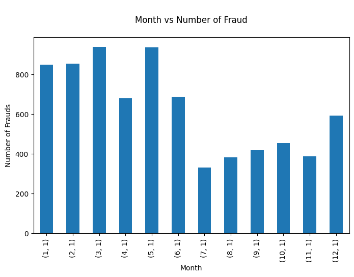

```python
viz_fraud = train_data[train_data['is_fraud'] == 1]

plt.figure(figsize=[8,5])
viz_fraud.groupby(['trans_month'])['is_fraud'].value_counts().plot.bar()
plt.title('\nMonth vs Number of Fraud\n')
plt.ylabel('Number of Frauds')
plt.xlabel('Month')
plt.show()
```

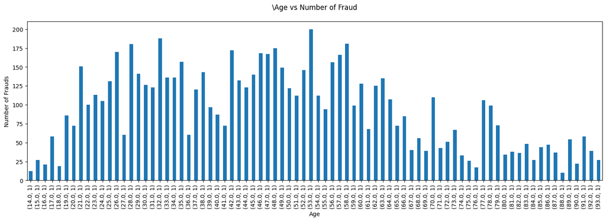

```python
plt.figure(figsize=[18,5])
viz_fraud.groupby(['trans_age'])['is_fraud'].value_counts().plot.bar()
plt.title('\Age vs Number of Fraud\n')
plt.ylabel('Number of Frauds')
plt.xlabel('Age')
plt.show()
```

## Cost Benefit Analysis before Fraud Detection by Model

```python
number_tran_per_month = train_data.groupby(['trans_month'])['cc_num'].count()
print(number_tran_per_month)
```

```
trans_month
1     104727
2      97657
3     143789
4     134970
5     146875
6     143811
7      86596
8      87359
9      70652
10     68758
11     70421
12    141060
Name: cc_num, dtype: int64
```

### Average Number of Monthly Transactions

```python
average_number_of_monthly_transaction = (round(sum(number_tran_per_month)/number_tran_per_month.count(), 2))
print(average_number_of_monthly_transaction)
```

```
108056.25
```

### Average Number of Monthly Fraudulent Transactions

```python
fraudulent_transaction = train_data[train_data['is_fraud'] == 1]
```

```python
fraudulent_transactions_per_month = fraudulent_transaction.groupby('trans_month')['cc_num'].count()
print(fraudulent_transactions_per_month)
```

```
trans_month
1     849
2     853
3     938
4     678
5     935
6     688
7     331
8     382
9     418
10    454
11    388
12    592
Name: cc_num, dtype: int64
```

```python
average_monthly_fraudulent_transactions = fraudulent_transactions_per_month.median()

print(average_monthly_fraudulent_transactions)
```

```
635.0
```

### Average Amount of Fraudulent Transaction

```python
average_amount_of_fraud_transaction = fraudulent_transaction.groupby(['trans_month'])['amt'].median()
average_amount_of_fraud_transaction = round(sum(average_amount_of_fraud_transaction), 2)/average_amount_of_fraud_transaction.count()
print(round(average_amount_of_fraud_transaction, 2))
```

```
461.56
```

### Cost Incurred before model deployment

```python
cost_incurred_before = average_monthly_fraudulent_transactions * average_amount_of_fraud_transaction
print(round(cost_incurred_before, 2))
```

```
293091.13
```

```python
#Dropping unnecessary columns
train_data.drop(['trans_date_trans_time','city','lat','long','job','state','dob','merch_lat','merch_long','trans_date'],axis=1,inplace=True)
test_data.drop(['trans_date_trans_time','city','lat','long','job','dob','state','merch_lat','merch_long','trans_date'],axis=1,inplace=True)
```

```python
train_data.shape
```

```
(1296675, 20)
```

```python
test_data.shape
```

```
(555719, 20)
```

```python
train_data.corr()  #finding the correlation
```

|  | cc_num | amt | gender | is_fraud | category_entertainment | category_food_dining | category_gas_transport | category_grocery_net | category_grocery_pos | category_health_fitness | category_home | category_kids_pets | category_misc_net | category_misc_pos | category_personal_care | category_shopping_net | category_shopping_pos | category_travel | trans_age | trans_month |
| --- | --- | --- | --- | --- | --- | --- | --- | --- | --- | --- | --- | --- | --- | --- | --- | --- | --- | --- | --- | --- |
| cc_num | 1.000000 | 0.001769 | 0.001112 | -0.000981 | -0.001274 | -0.000240 | -0.004438 | 0.002040 | 0.003191 | -0.000901 | 0.001548 | -0.000746 | 0.000898 | 0.001006 | 0.000685 | 0.000561 | -0.000364 | -0.001458 | -0.001224 | -0.000281 |
| amt | 0.001769 | 1.000000 | 0.001034 | 0.219404 | -0.010709 | -0.033102 | -0.014503 | -0.019831 | 0.094389 | -0.026860 | -0.024408 | -0.024701 | 0.014856 | -0.011905 | -0.038303 | 0.032153 | 0.018492 | 0.046097 | -0.009754 | -0.001748 |
| gender | 0.001112 | 0.001034 | 1.000000 | 0.007642 | 0.019591 | 0.010173 | -0.003029 | -0.003297 | 0.011994 | 0.011030 | 0.011206 | -0.005471 | -0.007138 | 0.007930 | -0.033654 | -0.011368 | -0.021437 | 0.018289 | 0.006037 | -0.000215 |
| is_fraud | -0.000981 | 0.219404 | 0.007642 | 1.000000 | -0.012200 | -0.015025 | -0.004851 | -0.007136 | 0.035558 | -0.014885 | -0.017848 | -0.014967 | 0.025886 | -0.008937 | -0.012167 | 0.044261 | 0.005955 | -0.006924 | 0.012250 | -0.012409 |
| category_entertainment | -0.001274 | -0.010709 | 0.019591 | -0.012200 | 1.000000 | -0.077021 | -0.093991 | -0.053289 | -0.090771 | -0.074462 | -0.090558 | -0.086402 | -0.063333 | -0.071529 | -0.076702 | -0.079742 | -0.087916 | -0.050207 | 0.001056 | 0.000403 |
| category_food_dining | -0.000240 | -0.033102 | 0.010173 | -0.015025 | -0.077021 | 1.000000 | -0.092607 | -0.052504 | -0.089435 | -0.073366 | -0.089225 | -0.085130 | -0.062401 | -0.070476 | -0.075574 | -0.078569 | -0.086622 | -0.049468 | -0.018709 | 0.000142 |
| category_gas_transport | -0.004438 | -0.014503 | -0.003029 | -0.004851 | -0.093991 | -0.092607 | 1.000000 | -0.064072 | -0.109139 | -0.089530 | -0.108884 | -0.103886 | -0.076149 | -0.086004 | -0.092224 | -0.095879 | -0.105706 | -0.060367 | 0.038647 | 0.000222 |
| category_grocery_net | 0.002040 | -0.019831 | -0.003297 | -0.007136 | -0.053289 | -0.052504 | -0.064072 | 1.000000 | -0.061877 | -0.050759 | -0.061732 | -0.058899 | -0.043173 | -0.048760 | -0.052287 | -0.054359 | -0.059931 | -0.034226 | -0.078823 | 0.000216 |
| category_grocery_pos | 0.003191 | 0.094389 | 0.011994 | 0.035558 | -0.090771 | -0.089435 | -0.109139 | -0.061877 | 1.000000 | -0.086463 | -0.105153 | -0.100327 | -0.073541 | -0.083057 | -0.089064 | -0.092594 | -0.102085 | -0.058299 | 0.018152 | -0.001745 |
| category_health_fitness | -0.000901 | -0.026860 | 0.011030 | -0.014885 | -0.074462 | -0.073366 | -0.089530 | -0.050759 | -0.086463 | 1.000000 | -0.086260 | -0.082301 | -0.060328 | -0.068134 | -0.073062 | -0.075958 | -0.083743 | -0.047824 | -0.000072 | -0.002282 |
| category_home | 0.001548 | -0.024408 | 0.011206 | -0.017848 | -0.090558 | -0.089225 | -0.108884 | -0.061732 | -0.105153 | -0.086260 | 1.000000 | -0.100092 | -0.073369 | -0.082863 | -0.088856 | -0.092378 | -0.101846 | -0.058163 | 0.014019 | 0.000386 |
| category_kids_pets | -0.000746 | -0.024701 | -0.005471 | -0.014967 | -0.086402 | -0.085130 | -0.103886 | -0.058899 | -0.100327 | -0.082301 | -0.100092 | 1.000000 | -0.070001 | -0.079060 | -0.084777 | -0.088138 | -0.097171 | -0.055493 | 0.020446 | 0.000473 |
| category_misc_net | 0.000898 | 0.014856 | -0.007138 | 0.025886 | -0.063333 | -0.062401 | -0.076149 | -0.043173 | -0.073541 | -0.060328 | -0.073369 | -0.070001 | 1.000000 | -0.057952 | -0.062143 | -0.064606 | -0.071228 | -0.040677 | 0.002554 | -0.000376 |
| category_misc_pos | 0.001006 | -0.011905 | 0.007930 | -0.008937 | -0.071529 | -0.070476 | -0.086004 | -0.048760 | -0.083057 | -0.068134 | -0.082863 | -0.079060 | -0.057952 | 1.000000 | -0.070185 | -0.072966 | -0.080445 | -0.045941 | -0.027804 | 0.001771 |
| category_personal_care | 0.000685 | -0.038303 | -0.033654 | -0.012167 | -0.076702 | -0.075574 | -0.092224 | -0.052287 | -0.089064 | -0.073062 | -0.088856 | -0.084777 | -0.062143 | -0.070185 | 1.000000 | -0.078244 | -0.086263 | -0.049263 | 0.015770 | 0.000642 |
| category_shopping_net | 0.000561 | 0.032153 | -0.011368 | 0.044261 | -0.079742 | -0.078569 | -0.095879 | -0.054359 | -0.092594 | -0.075958 | -0.092378 | -0.088138 | -0.064606 | -0.072966 | -0.078244 | 1.000000 | -0.089682 | -0.051216 | -0.016707 | -0.000293 |
| category_shopping_pos | -0.000364 | 0.018492 | -0.021437 | 0.005955 | -0.087916 | -0.086622 | -0.105706 | -0.059931 | -0.102085 | -0.083743 | -0.101846 | -0.097171 | -0.071228 | -0.080445 | -0.086263 | -0.089682 | 1.000000 | -0.056465 | -0.017265 | -0.000013 |
| category_travel | -0.001458 | 0.046097 | 0.018289 | -0.006924 | -0.050207 | -0.049468 | -0.060367 | -0.034226 | -0.058299 | -0.047824 | -0.058163 | -0.055493 | -0.040677 | -0.045941 | -0.049263 | -0.051216 | -0.056465 | 1.000000 | 0.020689 | 0.000914 |
| trans_age | -0.001224 | -0.009754 | 0.006037 | 0.012250 | 0.001056 | -0.018709 | 0.038647 | -0.078823 | 0.018152 | -0.000072 | 0.014019 | 0.020446 | 0.002554 | -0.027804 | 0.015770 | -0.016707 | -0.017265 | 0.020689 | 1.000000 | 0.006651 |
| trans_month | -0.000281 | -0.001748 | -0.000215 | -0.012409 | 0.000403 | 0.000142 | 0.000222 | 0.000216 | -0.001745 | -0.002282 | 0.000386 | 0.000473 | -0.000376 | 0.001771 | 0.000642 | -0.000293 | -0.000013 | 0.000914 | 0.006651 | 1.000000 |

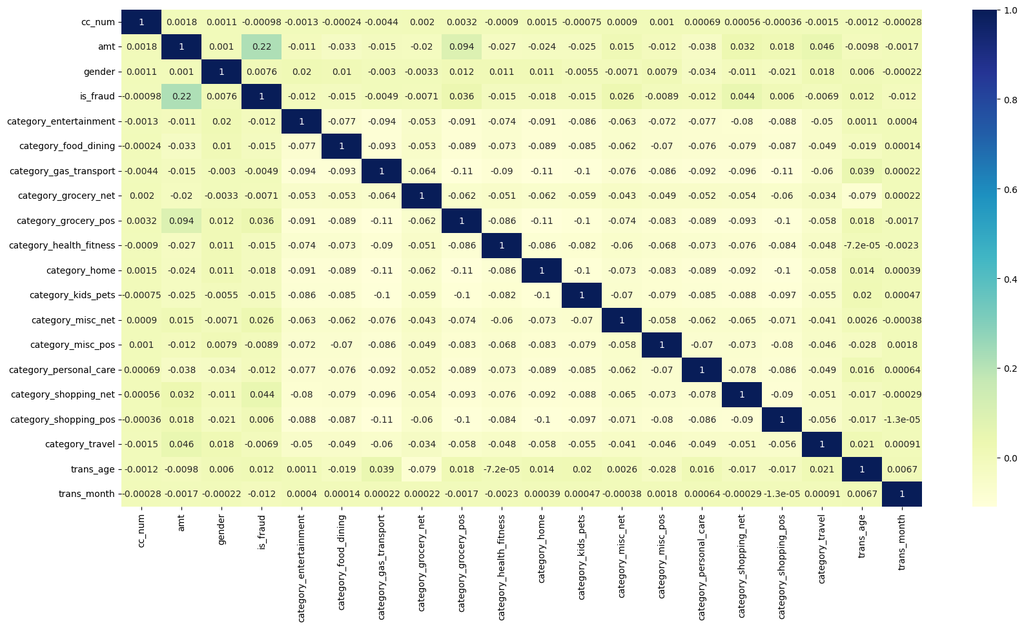

```python
#plot a heatmap to show correlation
plt.figure(figsize = (20, 10))
sns.heatmap(train_data.corr(), annot = True, cmap="YlGnBu")
plt.show()
```

## Step 5: Checking for Skewness

We use skewness analysis in the dataset to gain insights and potentially address skewness issues

```python
numerical_features = train_data.select_dtypes(include=[np.number])
skewness = numerical_features.apply(lambda x: skew(x))

# Display skewness for all numerical features
print(skewness)
```

```
cc_num                      2.851876
amt                        42.277825
gender                      0.190655
is_fraud                   13.029107
category_entertainment      3.297049
category_food_dining        3.354585
category_gas_transport      2.638513
category_grocery_net        5.056162
category_grocery_pos        2.755553
category_health_fitness     3.488522
category_home               2.763536
category_kids_pets          2.926934
category_misc_net           4.188092
category_misc_pos           3.652956
category_personal_care      3.370821
category_shopping_net       3.220980
category_shopping_pos       2.865785
category_travel             5.389191
trans_age                   0.610883
trans_month                 0.298515
dtype: float64
```

# Here,A skewness value of 42.28 for the 'amt' (transaction amount) feature indicates that the distribution of transaction amounts is highly positively skewed (right-skewed).

# This skewness value suggests that there may be a small number of transactions with very high amounts that are causing the right-skew in the distribution.

# Other features do not have such high skewness value,so it does not required much things do with it ,except 'is_fraud' skewness whose value might be high due to class imbalance

# To address the skewness, we might consider applying a data transformation to the 'amt' feature. One common approach is to use a log transformation, which can help make the distribution more symmetric by compressing the range of higher values.

```python
train_data['amt'] = np.log1p(train_data['amt'])
```

# By taking the logarithm of the transaction amounts using np.log1p(), we can reduce the impact of extreme high values and potentially make the distribution closer to a normal distribution. After the transformation, we can check the skewness of the 'amt_log' feature to see if it has reduced.

```python
#finding the skewness of 'amt' features
amt = skew(train_data['amt'])
print(f"Skewness of 'amt' feature: {amt:.2f}")
```

```
Skewness of 'amt' feature: -0.30
```

# A skewness of -0.30 for the 'amt' feature indicates that the logarithmic transformation has successfully reduced the skewness and made the distribution of transaction amounts more symmetric.

# A skewness value close to zero (-0.30 in this case) suggests that the distribution is approximately symmetric.

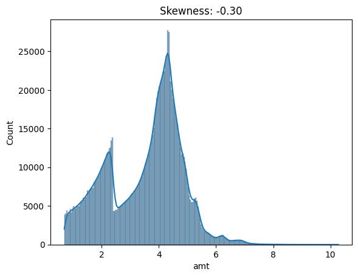

```python
#Understanding skewness by plotting a graph
sns.histplot(train_data['amt'], kde=True)
plt.title(f'Skewness: {amt:.2f}')
plt.show()
```

```python
from scipy.stats import skew

# Calculate the skewness of the 'is_fraud' feature
skewness_is_fraud = skew(train_data['is_fraud'])

# Print the skewness
print(f"Skewness of 'is_fraud' feature: {skewness_is_fraud:.2f}")
```

```
Skewness of 'is_fraud' feature: 13.03
```

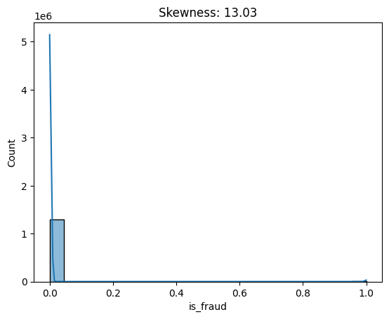

```python
sns.histplot(train_data['is_fraud'], kde=True)
plt.title(f'Skewness: {skewness["is_fraud"]:.2f}')
plt.show()
```

## Step 6:Splitting Data into Train and Test Set

```python
X_train = train_data.drop('is_fraud', axis=1)
y_train = train_data['is_fraud']
X_test = test_data.drop('is_fraud', axis=1)
y_test = test_data['is_fraud']
```

```python
#Standardizing the dataset
from sklearn.preprocessing import StandardScaler
scaler = StandardScaler()
X_train = scaler.fit_transform(X_train)
X_test = scaler.fit_transform(X_test)
```

## Step 7 : Handling Data imbalance

```python
# Using ADASYN or SMOTE to oversample

#ADASYN
from sklearn.linear_model import LogisticRegression
from imblearn.over_sampling import  SMOTE,ADASYN  #import SMOTE or ADASYN libraries
X_resampled, y_resampled=ADASYN().fit_resample(X_train, y_train) #fit train dataset into ADASYN to oversample
from collections import Counter
print(sorted(Counter(y_resampled).items()))
clf_adasyn = LogisticRegression().fit(X_resampled, y_resampled)

#SMOTE
X_resampled, y_resampled=SMOTE().fit_resample(X_train, y_train)
print(sorted(Counter(y_resampled).items())) #fit train dataset into SMOTE to oversample

clf_smote = LogisticRegression().fit(X_resampled, y_resampled)
```

```
[(0, 1289169), (1, 1288586)]
[(0, 1289169), (1, 1289169)]
```

```python
from sklearn.metrics import accuracy_score


# Using ADASYN

y_pred_adasyn = clf_adasyn.predict(X_test)
accuracy_adasyn = accuracy_score(y_test, y_pred_adasyn)

# Using SMOTE

y_pred_smote = clf_smote.predict(X_test)
accuracy_smote = accuracy_score(y_test, y_pred_smote)

# Print the accuracy scores
print("Accuracy for ADASYN:", accuracy_adasyn)
print("Accuracy for SMOTE:", accuracy_smote)
```

```
Accuracy for ADASYN: 0.7815514675582443
Accuracy for SMOTE: 0.9210284334348835
```

```python
X_test.shape,X_train.shape
```

```
((555719, 19), (1296675, 19))
```

## Step 8: Model Evaluation

#### Model 1:Simple Logistic Regression

```python
from sklearn.linear_model import LogisticRegression
from sklearn.model_selection import StratifiedKFold

from sklearn.metrics import accuracy_score, precision_score, recall_score, f1_score

# Define the number of folds
n_splits = 5  # You can adjust this number as needed

# Initialize the StratifiedKFold object
stratified_kfold = StratifiedKFold(n_splits=n_splits, shuffle=True, random_state=42)


# Initialize lists to store evaluation metrics for Logistic Regression
lr_accuracy_scores = []
lr_precision_scores = []
lr_recall_scores = []
lr_f1_scores = []

# Perform cross-validation for Logistic Regression
for train_index, test_index in stratified_kfold.split(X_train, y_train):
    X_train_fold, X_test_fold = X_train[train_index], X_train[test_index]
    y_train_fold, y_test_fold = y_train[train_index], y_train[test_index]

    # Initialize and train the Logistic Regression classifier
    lr_classifier = LogisticRegression(random_state=42)
    lr_classifier.fit(X_train, y_train)

    # Make predictions on the test set
    y_pred_lr = lr_classifier.predict(X_test_fold)

    # Calculate evaluation metrics for Logistic Regression
    accuracy_lr = accuracy_score(y_test_fold, y_pred_lr)
    precision_lr = precision_score(y_test_fold, y_pred_lr)
    recall_lr = recall_score(y_test_fold, y_pred_lr)
    f1_lr = f1_score(y_test_fold, y_pred_lr)

    # Append the scores to the lists
    lr_accuracy_scores.append(accuracy_lr)
    lr_precision_scores.append(precision_lr)
    lr_recall_scores.append(recall_lr)
    lr_f1_scores.append(f1_lr)

# Calculate the average scores across all folds for Logistic Regression
avg_accuracy_lr = np.mean(lr_accuracy_scores)
avg_precision_lr = np.mean(lr_precision_scores)
avg_recall_lr = np.mean(lr_recall_scores)
avg_f1_lr = np.mean(lr_f1_scores)

# Print the average scores for Logistic Regression
print("Logistic Regression Classifier:")
print(f'Average Accuracy: {avg_accuracy_lr:.2f}')
print(f'Average Precision: {avg_precision_lr:.2f}')
print(f'Average Recall: {avg_recall_lr:.2f}')
print(f'Average F1 Score: {avg_f1_lr:.2f}')
```

```
Logistic Regression Classifier:
Average Accuracy: 0.99
Average Precision: 0.01
Average Recall: 0.00
Average F1 Score: 0.00
```

#### Model 2: RandomForestClassifier

```python
from sklearn.ensemble import RandomForestClassifier

# Perform cross-validation for RandomForestClassifier
for train_index, test_index in stratified_kfold.split(X_train, y_train):
    X_train_fold, X_test_fold = X_train[train_index], X_train[test_index]
    y_train_fold, y_test_fold = y_train[train_index], y_train[test_index]

# Initialize lists to store evaluation metrics
avg_accuracy_scores = []
avg_precision_scores = []
avg_recall_scores = []
avg_f1_scores = []
fraud_accuracy_scores = []
fraud_precision_scores = []
fraud_recall_scores = []
fraud_f1_scores = []
non_fraud_accuracy_scores = []
non_fraud_precision_scores = []
non_fraud_recall_scores = []
non_fraud_f1_scores = []

 # Initialize and train the Random Forest classifier
rf = RandomForestClassifier(random_state=42)
rf.fit(X_train, y_train)

# Make predictions on the test set
y_pred = rf.predict(X_test)

 # Calculate evaluation metrics
accuracy = accuracy_score(y_test, y_pred)
precision = precision_score(y_test, y_pred)
recall = recall_score(y_test, y_pred)
f1 = f1_score(y_test, y_pred)

# Append the scores to the lists
avg_accuracy_scores.append(accuracy)
avg_precision_scores.append(precision)
avg_recall_scores.append(recall)
avg_f1_scores.append(f1)

 # Calculate individual scores for fraud and non-fraud classes
fraud_case = y_test == 1
non_fraud_case = y_test == 0

fraud_accuracy = accuracy_score(y_test[fraud_case], y_pred[fraud_case])
fraud_precision = precision_score(y_test[fraud_case], y_pred[fraud_case])
fraud_recall = recall_score(y_test[fraud_case], y_pred[fraud_case])
fraud_f1 = f1_score(y_test[fraud_case], y_pred[fraud_case])



non_fraud_accuracy = accuracy_score(y_test[non_fraud_case], y_pred[non_fraud_case])
non_fraud_precision = precision_score(y_test[non_fraud_case], y_pred[non_fraud_case])
non_fraud_recall = recall_score(y_test[non_fraud_case], y_pred[non_fraud_case])
non_fraud_f1 = f1_score(y_test[non_fraud_case], y_pred[non_fraud_case])

fraud_accuracy_scores.append(fraud_accuracy)
fraud_precision_scores.append(fraud_precision)
fraud_recall_scores.append(fraud_recall)
fraud_f1_scores.append(fraud_f1)

non_fraud_accuracy_scores.append(non_fraud_accuracy)
non_fraud_precision_scores.append(non_fraud_precision)
non_fraud_recall_scores.append(non_fraud_recall)
non_fraud_f1_scores.append(non_fraud_f1)

# Calculate the average scores across all folds
avg_accuracy = np.mean(avg_accuracy_scores)
avg_precision = np.mean(avg_precision_scores)
avg_recall = np.mean(avg_recall_scores)
avg_f1 = np.mean(avg_f1_scores)

# Calculate the average scores for fraud and non-fraud classes
avg_fraud_accuracy = np.mean(fraud_accuracy_scores)
avg_fraud_precision = np.mean(fraud_precision_scores)
avg_fraud_recall = np.mean(fraud_recall_scores)
avg_fraud_f1 = np.mean(fraud_f1_scores)

avg_non_fraud_accuracy = np.mean(non_fraud_accuracy_scores)
avg_non_fraud_precision = np.mean(non_fraud_precision_scores)
avg_non_fraud_recall = np.mean(non_fraud_recall_scores)
avg_non_fraud_f1 = np.mean(non_fraud_f1_scores)

# Print the average scores and individual scores
print("Random Forest Classifier - Average Scores:")
print(f'Average Accuracy: {avg_accuracy:.2f}')
print(f'Average Precision: {avg_precision:.2f}')
print(f'Average Recall: {avg_recall:.2f}')
print(f'Average F1 Score: {avg_f1:.2f}')

print("Random Forest Classifier - Fraud Class Scores:")
print(f'Average Accuracy for Fraud Class: {avg_fraud_accuracy:.2f}')
print(f'Average Precision for Fraud Class: {avg_fraud_precision:.2f}')
print(f'Average Recall for Fraud Class: {avg_fraud_recall:.2f}')
print(f'Average F1 Score for Fraud Class: {avg_fraud_f1:.2f}')

print("Random Forest Classifier - Non-Fraud Class Scores:")
print(f'Average Accuracy for Non-Fraud Class: {avg_non_fraud_accuracy:.2f}')
print(f'Average Precision for Non-Fraud Class: {avg_non_fraud_precision:.2f}')
print(f'Average Recall for Non-Fraud Class: {avg_non_fraud_recall:.2f}')
print(f'Average F1 Score for Non-Fraud Class: {avg_non_fraud_f1:.2f}')
```

```
Random Forest Classifier - Average Scores:
Average Accuracy: 1.00
Average Precision: 0.58
Average Recall: 0.17
Average F1 Score: 0.26
Random Forest Classifier - Fraud Class Scores:
Average Accuracy for Fraud Class: 0.17
Average Precision for Fraud Class: 1.00
Average Recall for Fraud Class: 0.17
Average F1 Score for Fraud Class: 0.29
Random Forest Classifier - Non-Fraud Class Scores:
Average Accuracy for Non-Fraud Class: 1.00
Average Precision for Non-Fraud Class: 0.00
Average Recall for Non-Fraud Class: 0.00
Average F1 Score for Non-Fraud Class: 0.00
```

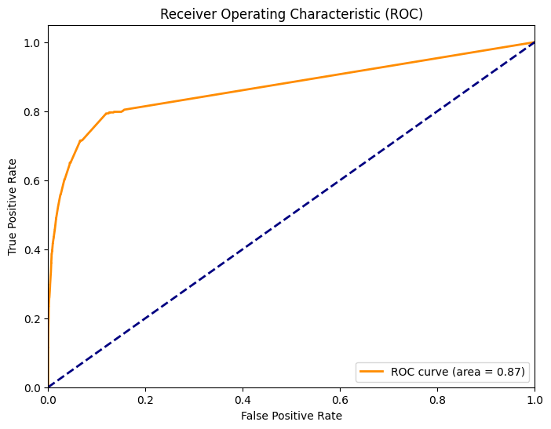

```python
from sklearn.metrics import roc_curve, auc


# Predict the probabilities for the positive class (class 1)
y_proba = rf.predict_proba(X_test)[:, 1]

# Calculate the ROC curve
fpr, tpr, thresholds = roc_curve(y_test, y_proba)

# Calculate the AUC (Area Under the Curve)
roc_auc = auc(fpr, tpr)

# Plot the ROC curve
plt.figure(figsize=(8, 6))
plt.plot(fpr, tpr, color='darkorange', lw=2, label='ROC curve (area = %0.2f)' % roc_auc)
plt.plot([0, 1], [0, 1], color='navy', lw=2, linestyle='--')
plt.xlim([0.0, 1.0])
plt.ylim([0.0, 1.05])
plt.xlabel('False Positive Rate')
plt.ylabel('True Positive Rate')
plt.title('Receiver Operating Characteristic (ROC)')
plt.legend(loc='lower right')
plt.show()
```

Model Performance: The closer the ROC curve is to the top-left corner and the larger the AUC, the better your model's performance. It signifies that the model can differentiate between the positive and negative classes effectively across various threshold settings.

The y-axis of the ROC curve represents the True Positive Rate (TPR), also known as Sensitivity or Recall. It measures the proportion of actual positive cases that the model correctly identifies as positive.

The x-axis of the ROC curve represents the False Positive Rate (FPR). It measures the proportion of actual negative cases that the model incorrectly classifies as positive

#### Model 3: Using DecisionTreeClassifier

```python
from sklearn.tree import DecisionTreeClassifier

# ... (similar code as the Random Forest section to load data, initialize StratifiedKFold, and lists)

# Perform cross-validation for DecisionTreeClassifier
for train_index, test_index in stratified_kfold.split(X_train, y_train):
    X_train_fold, X_test_fold = X_train[train_index], X_train[test_index]
    y_train_fold, y_test_fold = y_train[train_index], y_train[test_index]

# Initialize and train the Decision Tree classifier
dt_classifier = DecisionTreeClassifier(random_state=42)
dt_classifier.fit(X_train, y_train)

# Make predictions on the test set
y_pred = dt_classifier.predict(X_test)

# ... (similar code as the Random Forest section to calculate and append scores)
# Calculate evaluation metrics

accuracy = accuracy_score(y_test, y_pred)
precision = precision_score(y_test, y_pred)
recall = recall_score(y_test, y_pred)
f1 = f1_score(y_test, y_pred)

 # Append the scores to the lists
avg_accuracy_scores.append(accuracy)
avg_precision_scores.append(precision)
avg_recall_scores.append(recall)
avg_f1_scores.append(f1)

 # Calculate individual scores for fraud and non-fraud classes
fraud_case = y_test == 1
non_fraud_case = y_test == 0

fraud_accuracy = accuracy_score(y_test[fraud_case], y_pred[fraud_case])
fraud_precision = precision_score(y_test[fraud_case], y_pred[fraud_case])
fraud_recall = recall_score(y_test[fraud_case], y_pred[fraud_case])
fraud_f1 = f1_score(y_test[fraud_case], y_pred[fraud_case])



non_fraud_accuracy = accuracy_score(y_test[non_fraud_case], y_pred[non_fraud_case])
non_fraud_precision = precision_score(y_test[non_fraud_case], y_pred[non_fraud_case])
non_fraud_recall = recall_score(y_test[non_fraud_case], y_pred[non_fraud_case])
non_fraud_f1 = f1_score(y_test[non_fraud_case], y_pred[non_fraud_case])

fraud_accuracy_scores.append(fraud_accuracy)
fraud_precision_scores.append(fraud_precision)
fraud_recall_scores.append(fraud_recall)
fraud_f1_scores.append(fraud_f1)

non_fraud_accuracy_scores.append(non_fraud_accuracy)
non_fraud_precision_scores.append(non_fraud_precision)
non_fraud_recall_scores.append(non_fraud_recall)
non_fraud_f1_scores.append(non_fraud_f1)

# Calculate the average scores across all folds
avg_accuracy = np.mean(avg_accuracy_scores)
avg_precision = np.mean(avg_precision_scores)
avg_recall = np.mean(avg_recall_scores)
avg_f1 = np.mean(avg_f1_scores)

# Calculate the average scores for fraud and non-fraud classes
avg_fraud_accuracy = np.mean(fraud_accuracy_scores)
avg_fraud_precision = np.mean(fraud_precision_scores)
avg_fraud_recall = np.mean(fraud_recall_scores)
avg_fraud_f1 = np.mean(fraud_f1_scores)

avg_non_fraud_accuracy = np.mean(non_fraud_accuracy_scores)
avg_non_fraud_precision = np.mean(non_fraud_precision_scores)
avg_non_fraud_recall = np.mean(non_fraud_recall_scores)
avg_non_fraud_f1 = np.mean(non_fraud_f1_scores)

# Print the average scores and individual scores for Decision Tree
print("Decision Tree Classifier - Average Scores:")
# ... (similar code as the Random Forest section to print average and individual scores)
print(f'Average Accuracy: {avg_accuracy:.2f}')
print(f'Average Precision: {avg_precision:.2f}')
print(f'Average Recall: {avg_recall:.2f}')
print(f'Average F1 Score: {avg_f1:.2f}')

print("Decision Tree Classifier - Fraud Class Scores:")
print(f'Average Accuracy for Fraud Class: {avg_fraud_accuracy:.2f}')
print(f'Average Precision for Fraud Class: {avg_fraud_precision:.2f}')
print(f'Average Recall for Fraud Class: {avg_fraud_recall:.2f}')
print(f'Average F1 Score for Fraud Class: {avg_fraud_f1:.2f}')

print("Decision Tree Classifier - Non-Fraud Class Scores:")
print(f'Average Accuracy for Non-Fraud Class: {avg_non_fraud_accuracy:.2f}')
print(f'Average Precision for Non-Fraud Class: {avg_non_fraud_precision:.2f}')
print(f'Average Recall for Non-Fraud Class: {avg_non_fraud_recall:.2f}')
print(f'Average F1 Score for Non-Fraud Class: {avg_non_fraud_f1:.2f}')
```

```
Decision Tree Classifier - Average Scores:
Average Accuracy: 0.99
Average Precision: 0.34
Average Recall: 0.17
Average F1 Score: 0.19
Decision Tree Classifier - Fraud Class Scores:
Average Accuracy for Fraud Class: 0.17
Average Precision for Fraud Class: 1.00
Average Recall for Fraud Class: 0.17
Average F1 Score for Fraud Class: 0.29
Decision Tree Classifier - Non-Fraud Class Scores:
Average Accuracy for Non-Fraud Class: 1.00
Average Precision for Non-Fraud Class: 0.00
Average Recall for Non-Fraud Class: 0.00
Average F1 Score for Non-Fraud Class: 0.00
```

#### Model 4:Using Xgboost

```python
from xgboost import XGBClassifier

# ... (similar code as the Random Forest section to load data, initialize StratifiedKFold, and lists)

# Perform cross-validation for Xgboost
for train_index, test_index in stratified_kfold.split(X_train, y_train):
    X_train_fold, X_test_fold = X_train[train_index], X_train[test_index]
    y_train_fold, y_test_fold = y_train[train_index], y_train[test_index]

 # Initialize and train the XGBoost classifier
xgb_classifier = XGBClassifier(random_state=42)
xgb_classifier.fit(X_train, y_train)

# Make predictions on the test set
y_pred = xgb_classifier.predict(X_test)

 # ... (similar code as the Random Forest section to calculate and append scores)
accuracy = accuracy_score(y_test, y_pred)
precision = precision_score(y_test, y_pred)
recall = recall_score(y_test, y_pred)
f1 = f1_score(y_test, y_pred)

# Append the scores to the lists
avg_accuracy_scores.append(accuracy)
avg_precision_scores.append(precision)
avg_recall_scores.append(recall)
avg_f1_scores.append(f1)

# Calculate individual scores for fraud and non-fraud classes
fraud_case = y_test == 1
non_fraud_case = y_test == 0

fraud_accuracy = accuracy_score(y_test[fraud_case], y_pred[fraud_case])
fraud_precision = precision_score(y_test[fraud_case], y_pred[fraud_case])
fraud_recall = recall_score(y_test[fraud_case], y_pred[fraud_case])
fraud_f1 = f1_score(y_test[fraud_case], y_pred[fraud_case])



non_fraud_accuracy = accuracy_score(y_test[non_fraud_case], y_pred[non_fraud_case])
non_fraud_precision = precision_score(y_test[non_fraud_case], y_pred[non_fraud_case])
non_fraud_recall = recall_score(y_test[non_fraud_case], y_pred[non_fraud_case])
non_fraud_f1 = f1_score(y_test[non_fraud_case], y_pred[non_fraud_case])

fraud_accuracy_scores.append(fraud_accuracy)
fraud_precision_scores.append(fraud_precision)
fraud_recall_scores.append(fraud_recall)
fraud_f1_scores.append(fraud_f1)

non_fraud_accuracy_scores.append(non_fraud_accuracy)
non_fraud_precision_scores.append(non_fraud_precision)
non_fraud_recall_scores.append(non_fraud_recall)
non_fraud_f1_scores.append(non_fraud_f1)

# Calculate the average scores across all folds
avg_accuracy = np.mean(avg_accuracy_scores)
avg_precision = np.mean(avg_precision_scores)
avg_recall = np.mean(avg_recall_scores)
avg_f1 = np.mean(avg_f1_scores)

# Calculate the average scores for fraud and non-fraud classes
avg_fraud_accuracy = np.mean(fraud_accuracy_scores)
avg_fraud_precision = np.mean(fraud_precision_scores)
avg_fraud_recall = np.mean(fraud_recall_scores)
avg_fraud_f1 = np.mean(fraud_f1_scores)

avg_non_fraud_accuracy = np.mean(non_fraud_accuracy_scores)
avg_non_fraud_precision = np.mean(non_fraud_precision_scores)
avg_non_fraud_recall = np.mean(non_fraud_recall_scores)
avg_non_fraud_f1 = np.mean(non_fraud_f1_scores)


# Print the average scores and individual scores for XGBoost
print("XGBoost Classifier - Average Scores:")
# ... (similar code as the Random Forest section to print average and individual scores)
print(f'Average Accuracy: {avg_accuracy:.2f}')
print(f'Average Precision: {avg_precision:.2f}')
print(f'Average Recall: {avg_recall:.2f}')
print(f'Average F1 Score: {avg_f1:.2f}')

#Print the result for fraud and non-fraud class:
print("XGBoost Classifier - Fraud Class Scores:")
print(f'Average Accuracy for Fraud Class: {avg_fraud_accuracy:.2f}')
print(f'Average Precision for Fraud Class: {avg_fraud_precision:.2f}')
print(f'Average Recall for Fraud Class: {avg_fraud_recall:.2f}')
print(f'Average F1 Score for Fraud Class: {avg_fraud_f1:.2f}')

print("XGBoost Classifier - Non-Fraud Class Scores:")
print(f'Average Accuracy for Non-Fraud Class: {avg_non_fraud_accuracy:.2f}')
print(f'Average Precision for Non-Fraud Class: {avg_non_fraud_precision:.2f}')
print(f'Average Recall for Non-Fraud Class: {avg_non_fraud_recall:.2f}')
print(f'Average F1 Score for Non-Fraud Class: {avg_non_fraud_f1:.2f}')
```

```
XGBoost Classifier - Average Scores:
Average Accuracy: 0.99
Average Precision: 0.40
Average Recall: 0.16
Average F1 Score: 0.20
XGBoost Classifier - Fraud Class Scores:
Average Accuracy for Fraud Class: 0.16
Average Precision for Fraud Class: 1.00
Average Recall for Fraud Class: 0.16
Average F1 Score for Fraud Class: 0.28
XGBoost Classifier - Non-Fraud Class Scores:
Average Accuracy for Non-Fraud Class: 1.00
Average Precision for Non-Fraud Class: 0.00
Average Recall for Non-Fraud Class: 0.00
Average F1 Score for Non-Fraud Class: 0.00
```

### Step 9:Prediction on test set

```python
y_test_pred = rf.predict(X_test)
y_test_pred[:10]
```

```
array([0, 0, 0, 0, 0, 0, 0, 0, 0, 0])
```

### Testing model on original data without oversampling

```python
y_train_pred = rf.predict(X_train)
y_test_pred = rf.predict(X_test)
```

```python
from sklearn.metrics import confusion_matrix
cm = confusion_matrix(y_test, y_test_pred)
print("Confusion Matrix:")
print(cm)
```

```
Confusion Matrix:
[[553312    262]
 [  1785    360]]
```

```python
from sklearn.metrics import accuracy_score
accuracy = accuracy_score(y_test, y_test_pred)
print(f"Accuracy: {accuracy:.2f}")
```

```
Accuracy: 1.00
```

```python
from sklearn.metrics import precision_recall_curve
precision, recall, thresholds = precision_recall_curve(y_test, y_test_pred)
from sklearn.metrics import f1_score
f1 = f1_score(y_test, y_test_pred)
print(f"F1-Score: {f1:.2f}")
```

```
F1-Score: 0.26
```

### Converting y_test_pred to a Data Frame

```python
y_test_pred1 = pd.DataFrame(y_test_pred)
y_test_pred1.head()
```

|  | 0 |
| --- | --- |
| 0 | 0 |
| 1 | 0 |
| 2 | 0 |
| 3 | 0 |
| 4 | 0 |

### Adding 'trans_num' as index

```python
y_test_df = pd.DataFrame(y_test)
y_test_df['trans_num'] = y_test_df.index
```

#### Merging y_test_df and y_test_pred_df

```python
y_test_pred1.reset_index(drop=True, inplace=True)
y_test_df.reset_index(drop=True, inplace=True)

final_y_pred = pd.concat([y_test_df, y_test_pred1],axis=1)

final_y_pred.head()
```

|  | is_fraud | trans_num | 0 |
| --- | --- | --- | --- |
| 0 | 0 | 0 | 0 |
| 1 | 0 | 1 | 0 |
| 2 | 0 | 2 | 0 |
| 3 | 0 | 3 | 0 |
| 4 | 0 | 4 | 0 |

#### Renaming column name '0' to 'Predictable_Value'

```python
final_y_pred = final_y_pred.rename(columns={ 0 : 'Predictable_Value'})

final_y_pred.head()
```

|  | is_fraud | trans_num | Predictable_Value |
| --- | --- | --- | --- |
| 0 | 0 | 0 | 0 |
| 1 | 0 | 1 | 0 |
| 2 | 0 | 2 | 0 |
| 3 | 0 | 3 | 0 |
| 4 | 0 | 4 | 0 |

#### Predicting Test Set

```python
final_y_pred['fraud_prediction'] = final_y_pred.Predictable_Value.map(lambda x: 1 if x>0. else 0)
final_y_pred.head()
```

|  | is_fraud | trans_num | Predictable_Value | fraud_prediction |
| --- | --- | --- | --- | --- |
| 0 | 0 | 0 | 0 | 0 |
| 1 | 0 | 1 | 0 | 0 |
| 2 | 0 | 2 | 0 | 0 |
| 3 | 0 | 3 | 0 | 0 |
| 4 | 0 | 4 | 0 | 0 |

```python
#Predicting Probabilities on 'fraud_prediction'
final_prediction = final_y_pred['fraud_prediction']
final_prediction
```

```
0         0
1         0
2         0
3         0
4         0
         ..
555714    0
555715    0
555716    0
555717    0
555718    0
Name: fraud_prediction, Length: 555719, dtype: int64
```

```python
# Assuming 'final_y_pred' is a DataFrame containing 'fraud_prediction' and has an index that matches the test set
test_set = test_data.merge(final_y_pred[['fraud_prediction']], left_index=True, right_index=True, how='left')
test_set.head()
```

|  | cc_num | amt | gender | is_fraud | category_entertainment | category_food_dining | category_gas_transport | category_grocery_net | category_grocery_pos | category_health_fitness | ... | category_kids_pets | category_misc_net | category_misc_pos | category_personal_care | category_shopping_net | category_shopping_pos | category_travel | trans_age | trans_month | fraud_prediction |
| --- | --- | --- | --- | --- | --- | --- | --- | --- | --- | --- | --- | --- | --- | --- | --- | --- | --- | --- | --- | --- | --- |
| 0 | 2291163933867244 | 2.86 | 1 | 0 | 0 | 0 | 0 | 0 | 0 | 0 | ... | 0 | 0 | 0 | 1 | 0 | 0 | 0 | 52.0 | 6 | 0 |
| 1 | 3573030041201292 | 29.84 | 0 | 0 | 0 | 0 | 0 | 0 | 0 | 0 | ... | 0 | 0 | 0 | 1 | 0 | 0 | 0 | 30.0 | 6 | 0 |
| 2 | 3598215285024754 | 41.28 | 0 | 0 | 0 | 0 | 0 | 0 | 0 | 1 | ... | 0 | 0 | 0 | 0 | 0 | 0 | 0 | 49.0 | 6 | 0 |
| 3 | 3591919803438423 | 60.05 | 1 | 0 | 0 | 0 | 0 | 0 | 0 | 0 | ... | 0 | 0 | 1 | 0 | 0 | 0 | 0 | 32.0 | 6 | 0 |
| 4 | 3526826139003047 | 3.19 | 1 | 0 | 0 | 0 | 0 | 0 | 0 | 0 | ... | 0 | 0 | 0 | 0 | 0 | 0 | 1 | 64.0 | 6 | 0 |

5 rows × 21 columns

## **Cost Benefit Analysis after Fraud Detection by Model**

```python
test_set.groupby(['trans_month'])['is_fraud'].value_counts()
```

```
trans_month  is_fraud
6            0            29925
             1              133
7            0            85527
             1              321
8            0            88344
             1              415
9            0            69193
             1              340
10           0            68964
             1              384
11           0            72341
             1              294
12           0           139280
             1              258
Name: is_fraud, dtype: int64
```

```python
test_set.groupby(['trans_month'])['fraud_prediction'].value_counts()
```

```
trans_month  fraud_prediction
6            0                    30022
             1                       36
7            0                    85748
             1                      100
8            0                    88659
             1                      100
9            0                    69444
             1                       89
10           0                    69258
             1                       90
11           0                    72548
             1                       87
12           0                   139418
             1                      120
Name: fraud_prediction, dtype: int64
```

```python
fraud_data = test_set[test_set['fraud_prediction'] == 1]
fraud_data.head()
```

|  | cc_num | amt | gender | is_fraud | category_entertainment | category_food_dining | category_gas_transport | category_grocery_net | category_grocery_pos | category_health_fitness | ... | category_kids_pets | category_misc_net | category_misc_pos | category_personal_care | category_shopping_net | category_shopping_pos | category_travel | trans_age | trans_month | fraud_prediction |
| --- | --- | --- | --- | --- | --- | --- | --- | --- | --- | --- | --- | --- | --- | --- | --- | --- | --- | --- | --- | --- | --- |
| 767 | 2610529083834453 | 420.98 | 0 | 0 | 1 | 0 | 0 | 0 | 0 | 0 | ... | 0 | 0 | 0 | 0 | 0 | 0 | 0 | 25.0 | 6 | 1 |
| 2195 | 4005676619255478 | 326.94 | 1 | 1 | 0 | 0 | 0 | 0 | 1 | 0 | ... | 0 | 0 | 0 | 0 | 0 | 0 | 0 | 26.0 | 6 | 1 |
| 2258 | 3524574586339330 | 353.08 | 0 | 1 | 0 | 0 | 0 | 0 | 1 | 0 | ... | 0 | 0 | 0 | 0 | 0 | 0 | 0 | 34.0 | 6 | 1 |
| 2270 | 180094608895855 | 449.25 | 0 | 0 | 0 | 0 | 0 | 0 | 0 | 0 | ... | 0 | 1 | 0 | 0 | 0 | 0 | 0 | 59.0 | 6 | 1 |
| 6143 | 3596357274378601 | 461.23 | 1 | 0 | 0 | 0 | 0 | 0 | 0 | 0 | ... | 0 | 1 | 0 | 0 | 0 | 0 | 0 | 47.0 | 6 | 1 |

5 rows × 21 columns

#### Cost of providing customer support per month

```python
number_of_fraud_per_month = fraud_data.groupby(['trans_month'])['fraud_prediction'].count()
```

```python
TF = round(sum(number_of_fraud_per_month), 2)/number_of_fraud_per_month.count() #average number of transactions per month detected as fraudulent
print(round(TF, 2))
```

```
88.86
```

```python
total_service_cost = TF * 1.5
print(round(total_service_cost, 2))
```

```
133.29
```

#### Cost incurred due to these fraudulent transactions left undetected by the model

```python
undetected_fraud =test_set[(test_set['is_fraud'] == 1) & (test_set['fraud_prediction'] == 0)]

undetected_fraud.head()
```

|  | cc_num | amt | gender | is_fraud | category_entertainment | category_food_dining | category_gas_transport | category_grocery_net | category_grocery_pos | category_health_fitness | ... | category_kids_pets | category_misc_net | category_misc_pos | category_personal_care | category_shopping_net | category_shopping_pos | category_travel | trans_age | trans_month | fraud_prediction |
| --- | --- | --- | --- | --- | --- | --- | --- | --- | --- | --- | --- | --- | --- | --- | --- | --- | --- | --- | --- | --- | --- |
| 1685 | 3560725013359375 | 24.84 | 0 | 1 | 0 | 0 | 0 | 0 | 0 | 1 | ... | 0 | 0 | 0 | 0 | 0 | 0 | 0 | 50.0 | 6 | 0 |
| 1767 | 6564459919350820 | 780.52 | 1 | 1 | 0 | 0 | 0 | 0 | 0 | 0 | ... | 0 | 1 | 0 | 0 | 0 | 0 | 0 | 61.0 | 6 | 0 |
| 1781 | 6564459919350820 | 620.33 | 1 | 1 | 1 | 0 | 0 | 0 | 0 | 0 | ... | 0 | 0 | 0 | 0 | 0 | 0 | 0 | 61.0 | 6 | 0 |
| 1784 | 4005676619255478 | 1077.69 | 1 | 1 | 0 | 0 | 0 | 0 | 0 | 0 | ... | 0 | 0 | 0 | 0 | 1 | 0 | 0 | 26.0 | 6 | 0 |
| 1857 | 3560725013359375 | 842.65 | 0 | 1 | 0 | 0 | 0 | 0 | 0 | 0 | ... | 0 | 0 | 0 | 0 | 0 | 1 | 0 | 50.0 | 6 | 0 |

5 rows × 21 columns

```python
number_of_tran_per_month = undetected_fraud.groupby(['trans_month']).size()
```

```python
FN = sum(number_of_tran_per_month)/number_of_tran_per_month.count() #average number of transactions per month that are fraudulent but not detected by the model
print(round(FN, 2))
```

```
255.0
```

```python
# Calculate the incurred loss for the test data
incurred_loss = round((FN * average_amount_of_fraud_transaction), 2)

# Print the incurred loss
print(round(incurred_loss))
```

```
117698
```

#### Total Cost Incurred after model deployment

```python
cost_incurred_after = total_service_cost + incurred_loss
print(round(cost_incurred_after))
```

```
117831
```

#### Savings after model deployment

```python
savings = round((cost_incurred_before - cost_incurred_after), 2)
print(round(savings))
```

```
175260
```

```python
#Saving percentage
savings_percent = (savings/cost_incurred_before)*100
print(round(savings_percent, 2))
```

```
59.8
```